# Predicting Pine Tree Infestation

[figure not shown]

[figure not shown]

[figure not shown]

[figure not shown]

[figure not shown]

# Introduction to Dataset

### **Analytical Objective**

Estimate the minimum linear distance to the nearest brood tree (`DeadDist`) from tree-level and neighborhood-level measurements. The dashboard compares regularized and conventional regression approaches and summarizes model diagnostics for an academic data-science exercise. The `tidymodels` workflows use `sqrt(DeadDist)` as their outcome, so their RMSE values are reported on the square-root distance scale.

### **Data Dictionary for Selected Variables**

| Variables | Description | Type |
| --- | --- | --- |
| DeadDist | Minimum linear distance to nearest brood tree | Outcome |
| TreeDiam | Tree diameter | Predictor |
| Infest_Serv1 | Infestation severity of the nearest affected tree | Predictor |
| Ind_DeadDist | Indicator if nearest brood tree is within 50m effective distance found | Predictor |
| SDI_20th | Stand Density Index at 1/20th-acre neighborhood surrounding the tree | Predictor |
| BA_20th | Basal Area at 1/20th-acre neighborhood surrounding response tree | Predictor |
| Neigh_1/2th | Basal area total summed for all trees within 1/2th-acre neighborhood of response tree | Predictor |
| Neigh_1 | Basal area total summed for all trees within 1-acre neighborhood of response tree | Predictor |
| BA_Inf_20th | Basal area total for all infested trees within 1/20th-acre neighborhood | Predictor |
| BA_Infest_1/2th | Basal area of infested trees within 1/2th-acre neighborhood of response tree | Predictor |
| BA_Infest_1 | Basal area of infested trees within 1-acre neighborhood of response tree | Predictor |

### **Jeffrey Pine Beetle (JPB) Infestation Distribution in Lake Tahoe Basin in 1993**

[interactive chart not shown]

# Dataset summary

### **Original Dataset**

|  | TreeNum | Response | Easting | Northing | TreeDiam | Infest_Serv1 | Infest_Serv2 | Ind_DeadDist | DeadDist | SDI_20th | Neigh_SDI_1/4th | BA_20th | Neigh_1/4th | Neigh_1/2th | Neigh_1 | Neigh_1.5 | BA_Inf_20th | BA_Infest_1/4th | BA_Infest_1/2th | BA_Infest_1 | BA_Infest_1.5 | IND_BA_Infest_20th | IND_BA_Infest_1/4th | IND_BA_Infest_1/2th | IND_BA_Infest_1 | IND_BA_Infest_1.5 | Response_Factor |
| --- | --- | --- | --- | --- | --- | --- | --- | --- | --- | --- | --- | --- | --- | --- | --- | --- | --- | --- | --- | --- | --- | --- | --- | --- | --- | --- | --- |
| 1 | 1 | 0 | 766124.3808 | 4333846.342 | 7 | 15 | 24.128496 | 1 | 49.65012717 | 3.447468624181 | 14.14867197 | 1.843452 | 8.573688 | 21.745098 | 77.03775 | 112.76145 | 0 | 0 | 0 | 0 | 0 | 0 | 0 | 0 | 0 | 0 | Alive |
| 2 | 2 | 0 | 766138.6395 | 4333862.622 | 6 | 15 | 24.128496 | 1 | 31.57695778 | 5.612227883537 | 43.54438551 | 3.365118 | 30.02427 | 54.218214 | 126.740052 | 174.707982 | 0 | 0 | 0 | 5.34492 | 11.34432 | 0 | 0 | 0 | 1 | 1 | Alive |
| 3 | 3 | 0 | 766133.555 | 4333854.833 | 6 | 15 | 24.128496 | 1 | 38.51192214 | 6.538921492567 | 33.87840594 | 4.150494 | 22.235958 | 36.454536 | 95.941314 | 160.931178 | 0 | 0 | 0 | 0 | 7.52652 | 0 | 0 | 0 | 0 | 1 | Alive |
| 4 | 4 | 0 | 766142.1546 | 4333858.689 | 7 | 15 | 24.128496 | 1 | 29.12140948 | 18.217139960276 | 32.05986966 | 12.647826 | 21.919626 | 50.427684 | 112.696002 | 164.32902 | 0 | 0 | 0 | 9.375426 | 13.984056 | 0 | 0 | 0 | 1 | 1 | Alive |
| 5 | 5 | 0 | 766141.1526 | 4333857.993 | 12 | 15 | 24.128496 | 1 | 30.29468654 | 13.522204553376 | 33.39981135 | 9.484506 | 22.705002 | 49.505958 | 113.917698 | 154.506366 | 0 | 0 | 0 | 7.52652 | 11.34432 | 0 | 0 | 0 | 1 | 1 | Alive |
| 6 | 6 | 0 | 766142.0029 | 4333857.263 | 8 | 15 | 24.128496 | 1 | 29.74744285 | 13.522204553376 | 32.05986966 | 9.484506 | 21.919626 | 50.427684 | 104.940414 | 157.691502 | 0 | 0 | 0 | 7.52652 | 13.984056 | 0 | 0 | 0 | 1 | 1 | Alive |
| 7 | 7 | 0 | 766147.5703 | 4333858.562 | 14 | 15 | 24.128496 | 1 | 24.09804331 | 17.077681866668 | 40.08889683 | 12.102426 | 28.568052 | 66.413358 | 111.965166 | 169.45578 | 0 | 0 | 5.34492 | 11.34432 | 25.541082 | 0 | 0 | 1 | 1 | 1 | Alive |
| 8 | 8 | 0 | 766140.7057 | 4333853.88 | 8 | 15 | 24.128496 | 1 | 31.89620816 | 8.701482066946 | 41.19723249 | 5.355828 | 27.995382 | 36.86904 | 96.312186 | 157.249728 | 0 | 0 | 0 | 5.34492 | 13.984056 | 0 | 0 | 0 | 1 | 1 | Alive |
| 9 | 9 | 0 | 766141.393 | 4333853.84 | 15 | 15 | 24.128496 | 1 | 31.2374731 | 10.417554035286 | 41.19723249 | 6.424811999999999 | 27.995382 | 41.690376 | 95.183208 | 156.589794 | 0 | 0 | 0 | 5.34492 | 13.984056 | 0 | 0 | 0 | 1 | 1 | Alive |
| 10 | 10 | 0 | 766138.449 | 4333849.022 | 20 | 15 | 24.128496 | 1 | 35.4663525 | 8.455940728707 | 36.52002759 | 5.377644 | 24.46119 | 30.24243 | 81.084618 | 145.000044 | 0 | 0 | 0 | 1.396224 | 13.984056 | 0 | 0 | 0 | 1 | 1 | Alive |

[output cut: 9677 more lines]

### **Data summary for selected variables**

Data summary

| Name | Piped data |
| --- | --- |
| Number of rows | 9687 |
| Number of columns | 27 |
| _______________________ |  |
| Column type frequency: |  |
| factor | 1 |
| numeric | 26 |
| ________________________ |  |
| Group variables | None |

**Variable type: factor**

| skim_variable | n_missing | complete_rate | ordered | n_unique | top_counts |
| --- | --- | --- | --- | --- | --- |
| Response_Factor | 0 | 1 | FALSE | 2 | Ali: 8452, JPB: 1235 |

**Variable type: numeric**

| skim_variable | n_missing | complete_rate | mean | sd | p0 | p25 | p50 | p75 | p100 | hist |
| --- | --- | --- | --- | --- | --- | --- | --- | --- | --- | --- |
| TreeNum | 0 | 1 | 5213.18 | 3046.43 | 1.00 | 2612.50 | 5138.00 | 7580.50 | 10767.00 | ▇▇▇▇▆ |
| Response | 0 | 1 | 0.13 | 0.33 | 0.00 | 0.00 | 0.00 | 0.00 | 1.00 | ▇▁▁▁▁ |
| Easting | 0 | 1 | 766133.65 | 111.82 | 765805.15 | 766053.49 | 766138.97 | 766231.51 | 766328.96 | ▁▃▇▇▇ |
| Northing | 0 | 1 | 4334196.58 | 167.38 | 4333797.12 | 4334068.02 | 4334214.16 | 4334345.06 | 4334487.31 | ▂▅▇▇▇ |
| TreeDiam | 0 | 1 | 13.11 | 6.05 | 3.00 | 9.00 | 12.00 | 16.00 | 78.00 | ▇▂▁▁▁ |
| Infest_Serv1 | 0 | 1 | 10.70 | 18.26 | 1.00 | 1.00 | 3.00 | 11.00 | 85.00 | ▇▁▁▁▁ |
| Infest_Serv2 | 0 | 1 | 10.93 | 21.47 | 0.14 | 0.55 | 1.58 | 10.65 | 92.40 | ▇▁▁▁▁ |
| Ind_DeadDist | 0 | 1 | 0.90 | 0.29 | 0.00 | 1.00 | 1.00 | 1.00 | 1.00 | ▁▁▁▁▇ |
| DeadDist | 0 | 1 | 24.08 | 18.84 | 0.11 | 9.52 | 19.84 | 34.72 | 124.95 | ▇▃▁▁▁ |
| SDI_20th | 0 | 1 | 26.35 | 12.72 | 0.33 | 17.20 | 25.59 | 34.45 | 92.86 | ▅▇▂▁▁ |
| Neigh_SDI_1/4th | 0 | 1 | 104.60 | 40.54 | 4.04 | 75.51 | 107.09 | 133.26 | 221.05 | ▂▅▇▅▁ |
| BA_20th | 0 | 1 | 16.54 | 8.01 | 0.14 | 10.97 | 16.00 | 21.43 | 58.38 | ▅▇▂▁▁ |
| Neigh_1/4th | 0 | 1 | 66.17 | 25.02 | 1.95 | 49.24 | 66.61 | 83.13 | 140.46 | ▂▅▇▃▁ |
| Neigh_1/2th | 0 | 1 | 122.79 | 40.98 | 4.54 | 97.55 | 125.02 | 150.25 | 230.42 | ▁▃▇▆▁ |
| Neigh_1 | 0 | 1 | 228.42 | 67.85 | 13.03 | 188.71 | 236.04 | 273.86 | 391.42 | ▁▃▇▇▂ |
| Neigh_1.5 | 0 | 1 | 328.16 | 93.54 | 22.24 | 270.60 | 338.88 | 393.72 | 541.62 | ▁▂▆▇▂ |
| BA_Inf_20th | 0 | 1 | 0.60 | 1.91 | 0.00 | 0.00 | 0.00 | 0.00 | 21.88 | ▇▁▁▁▁ |
| BA_Infest_1/4th | 0 | 1 | 2.69 | 6.04 | 0.00 | 0.00 | 0.00 | 2.63 | 72.30 | ▇▁▁▁▁ |
| BA_Infest_1/2th | 0 | 1 | 5.26 | 9.77 | 0.00 | 0.00 | 0.89 | 7.11 | 92.40 | ▇▁▁▁▁ |
| BA_Infest_1 | 0 | 1 | 10.30 | 16.49 | 0.00 | 0.27 | 3.13 | 12.78 | 106.67 | ▇▁▁▁▁ |
| BA_Infest_1.5 | 0 | 1 | 15.05 | 22.09 | 0.00 | 1.37 | 7.75 | 17.07 | 135.70 | ▇▁▁▁▁ |
| IND_BA_Infest_20th | 0 | 1 | 0.21 | 0.41 | 0.00 | 0.00 | 0.00 | 0.00 | 1.00 | ▇▁▁▁▂ |
| IND_BA_Infest_1/4th | 0 | 1 | 0.46 | 0.50 | 0.00 | 0.00 | 0.00 | 1.00 | 1.00 | ▇▁▁▁▇ |
| IND_BA_Infest_1/2th | 0 | 1 | 0.62 | 0.48 | 0.00 | 0.00 | 1.00 | 1.00 | 1.00 | ▅▁▁▁▇ |
| IND_BA_Infest_1 | 0 | 1 | 0.76 | 0.43 | 0.00 | 1.00 | 1.00 | 1.00 | 1.00 | ▂▁▁▁▇ |
| IND_BA_Infest_1.5 | 0 | 1 | 0.86 | 0.35 | 0.00 | 1.00 | 1.00 | 1.00 | 1.00 | ▂▁▁▁▇ |

# Exploratory Analysis

### **Tree density And beetle population**

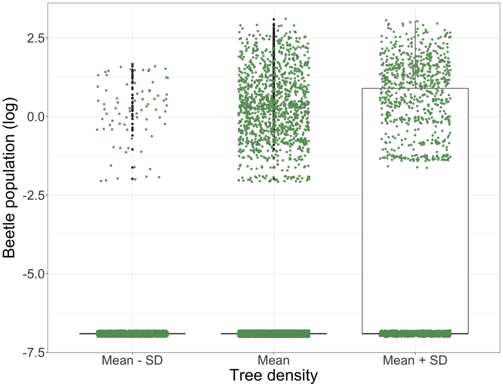

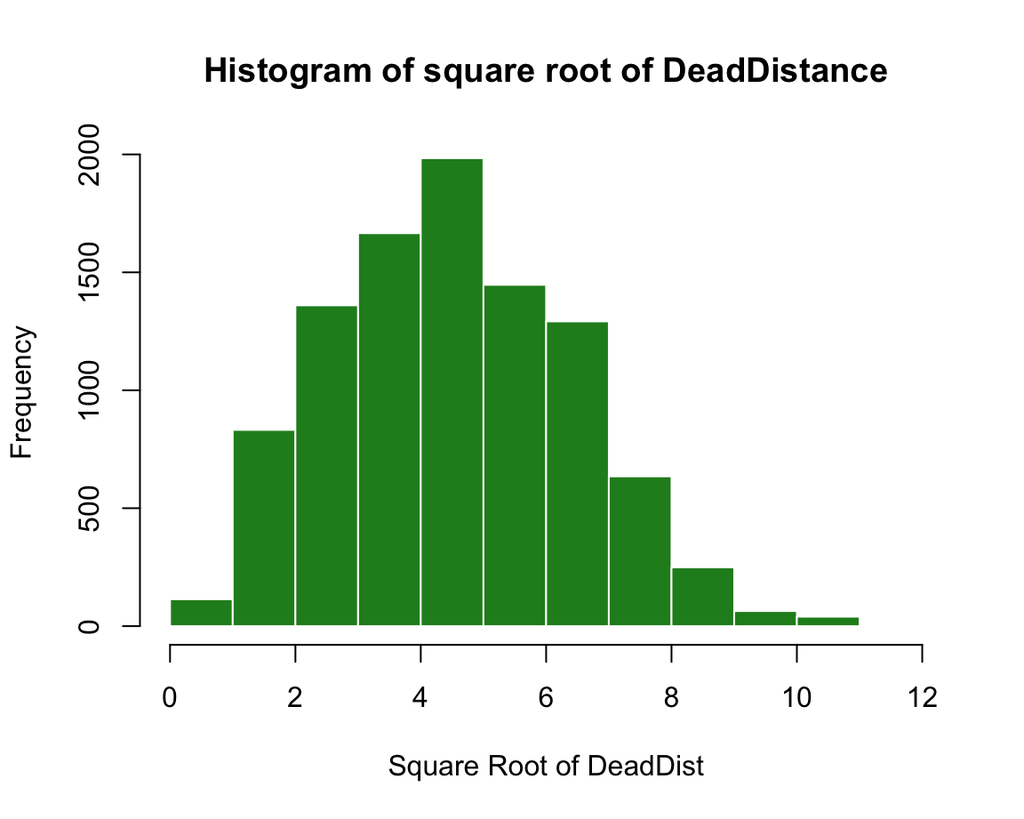

### **DeadDist vs TreeDiam**

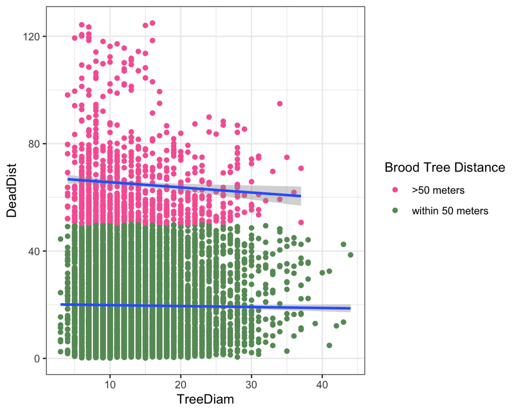

# Linear Regression Model

### **Linear Regression Model Check**

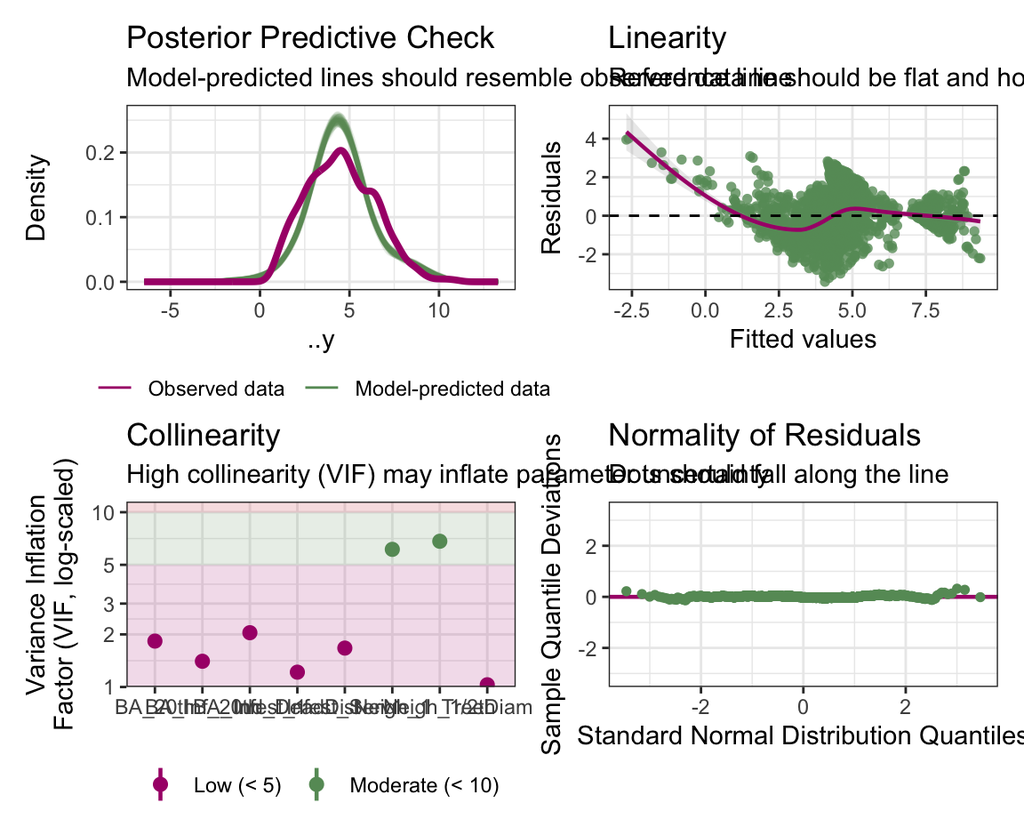

### **Model Estimates**

| term | estimate | std.error | statistic | p.value |
| --- | --- | --- | --- | --- |
| (Intercept) | 8.96 | 0.06 | 158.17 | 0.0 |
| TreeDiam | 0.00 | 0.00 | 1.65 | 0.1 |
| Infest_Serv1 | 0.01 | 0.00 | 13.25 | 0.0 |
| Ind_DeadDist | -2.68 | 0.04 | -62.52 | 0.0 |
| BA_20th | -0.01 | 0.00 | -3.20 | 0.0 |
| `Neigh_1/2th` | 0.00 | 0.00 | -5.99 | 0.0 |
| Neigh_1 | 0.00 | 0.00 | -11.05 | 0.0 |
| BA_Inf_20th | -0.27 | 0.01 | -38.12 | 0.0 |
| BA_Infest_1 | -0.03 | 0.00 | -30.51 | 0.0 |

### **Model Summary Statistics**

| r.squared | sigma | statistic | p.value | df | AIC |
| --- | --- | --- | --- | --- | --- |
| 0.65 | 1.13 | 2247.94 | 0 | 8 | 29819.16 |

### **Model Performance: R-squared ($R^2$)**

[interactive chart not shown]

### **Model Performance: Root Mean Square Error (RMSE)**

[interactive chart not shown]

# Regularization

### **RIDGE and LASSO**

**RIDGE** and **LASSO** regression are two types of regularized linear regression techniques used to prevent overfitting by penalizing large coefficients.  
**Ridge regression** adds an L2 penalty (squared magnitude of coefficients) to the loss function, which shrinks all coefficients but does not eliminate any, making it useful when all predictors are relevant.  
**Lasso regression**, on the other hand, adds an L1 penalty (absolute value of coefficients), which can shrink some coefficients to exactly zero, effectively performing variable selection.  
Both methods help improve model generalization, especially when dealing with multicollinearity or high-dimensional data.

### **RIDGE Regression Model Summary Statistics**

| term | estimate | penalty |
| --- | --- | --- |
| (Intercept) | 4.5364271 | 0.1629751 |
| TreeDiam | 0.0275966 | 0.1629751 |
| Infest_Serv1 | 0.1489799 | 0.1629751 |
| Ind_DeadDist | -0.7185500 | 0.1629751 |
| BA_20th | -0.1203665 | 0.1629751 |
| Neigh_1 | -0.4522609 | 0.1629751 |
| BA_Inf_20th | -0.4948580 | 0.1629751 |
| BA_Infest_1 | -0.4605808 | 0.1629751 |

### **Model Performance: R-squared ($R^2$) for RIDGE Model**

[interactive chart not shown]

### **RMSE: Root Mean Square Error for RIDGE Model**

[interactive chart not shown]

### **List of Predictors Retained via LASSO Regression Model**

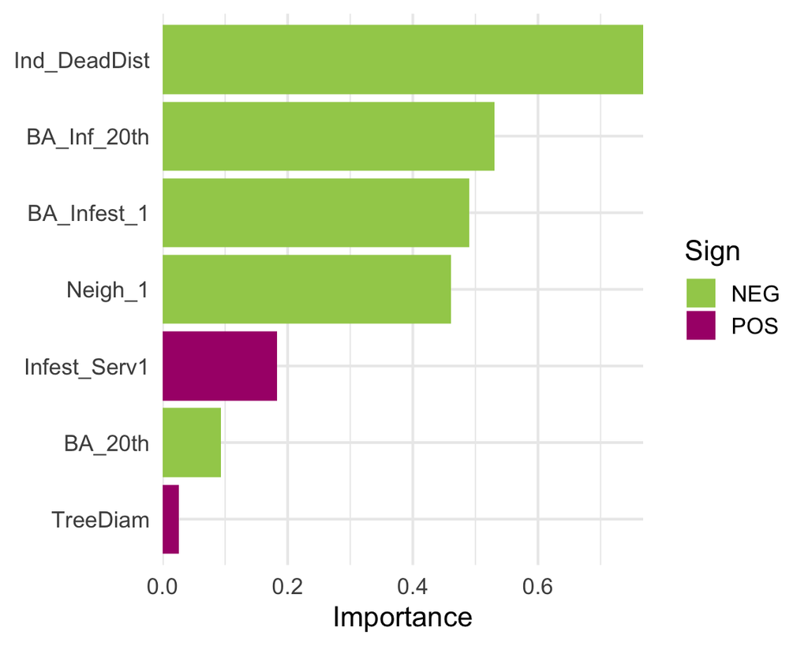

### **Model Performance: R-squared ($R^2$) for LASSO Model**

[interactive chart not shown]

### **RMSE: Root Mean Square Error for LASSO Model**

[interactive chart not shown]

````r
---
title: "Predicting Pine Tree Infestation"
subtitle: "HGEN 612: Methods in Data Science · Sina Mahdiani"
output:
  flexdashboard::flex_dashboard:
    orientation: columns
    vertical_layout: fill
    theme: sandstone
    source_code: embed
---
```{css, eval = TRUE, echo = FALSE}
.dataTables_scrollBody {
  max-height: 100% !important;
  max-width: 100% !important;
}
```

```{r setup, include=FALSE}
if (!file.exists("data/pine_beetle_1993.xlsx")) {
  stop(
    "This R Markdown file is not standalone. Download and extract the complete ",
    "GitHub repository, then run render_dashboard.R.",
    call. = FALSE
  )
}

library(flexdashboard)
library(tidymodels)      # for the parsnip package, along with the rest of tidymodels
library(tidyverse)       # for importing data
library(dotwhisker)      # for inspecting model coefficients
library(skimr)           # for variable summaries
library(patchwork)       # plot composer
library(broom.mixed)     # for converting bayesian model output to tidy tibbles
library(readxl)          # for reading an Excel file into a dataframe
library(broom)           # for converting model outputs into tidy data frames
library(car)             # for regression diagnostics and multicollinearity checks
library(ggfortify)       # for visualization
library(vip)             # for computing and visualizing variable importance in ML model
library(performance)     # for assessing model quality
library(plotly)          # for creating interactive plots
library(ggplot2)
library(knitr)
library(dplyr)
library(glmnet)
library(patchwork)
library(GGally)
library(corrr)
library(gt)
library(broom)
library(see)
```

```{r loadData, echo=FALSE}
# Load the course-provided dataset.
data_work1 <- read_excel("data/pine_beetle_1993.xlsx", sheet = 1)
data_work1 <- na.omit(data_work1)
```

Introduction to Dataset {data-navmenu="Dataset Overview"}
=====================================

Column {data-width=200}
-----------------------------------------------------------------------
### **Analytical Objective**

<div style="background:#f5f1e8; border-left:6px solid #5d7a32; padding:18px; border-radius:6px;">
Estimate the minimum linear distance to the nearest brood tree
(<code>DeadDist</code>) from tree-level and neighborhood-level measurements.
The dashboard compares regularized and conventional regression approaches and
summarizes model diagnostics for an academic data-science exercise.
The <code>tidymodels</code> workflows use <code>sqrt(DeadDist)</code> as their
outcome, so their RMSE values are reported on the square-root distance scale.
</div>


### **Data Dictionary for Selected Variables**

```{r Dictionary, echo=FALSE}
# Select variables and make a dictionary

data.frame(
  Variables = c("DeadDist", "TreeDiam", "Infest_Serv1", "Ind_DeadDist",
                "SDI_20th", "BA_20th", "Neigh_1/2th", "Neigh_1",
                "BA_Inf_20th", "BA_Infest_1/2th", "BA_Infest_1"),

  Description = c("Minimum linear distance to nearest brood tree",
                  "Tree diameter",
                  "Infestation severity of the nearest affected tree",
                  "Indicator if nearest brood tree is within 50m effective distance found",
                  "Stand Density Index at 1/20th-acre neighborhood surrounding the tree",
                  "Basal Area at 1/20th-acre neighborhood surrounding response tree",
                  "Basal area total summed for all trees within 1/2th-acre neighborhood of response tree",
                  "Basal area total summed for all trees within 1-acre neighborhood of response tree",
                  "Basal area total for all infested trees within 1/20th-acre neighborhood",
                  "Basal area of infested trees within 1/2th-acre neighborhood of response tree",
                  "Basal area of infested trees within 1-acre neighborhood of response tree"),

  Type = c("Outcome", "Predictor", "Predictor", "Predictor",
                           "Predictor", "Predictor", "Predictor", "Predictor",
                           "Predictor", "Predictor", "Predictor")) %>%
  kable()



```


Column {data-width=350}
-----------------------------------------------------------------------

### **Jeffrey Pine Beetle (JPB) Infestation Distribution in Lake Tahoe Basin in 1993**

```{r ggplot, echo=FALSE}
# Convert Response to a factor before plotting
data_work1$Response_Factor <- factor(data_work1$Response, labels = c("Alive", "JPB-attacked"))
# Create ggplot
plot1 <- ggplot(data = data_work1, aes(x = Easting, y = Northing)) +
  geom_point(aes(
    color = Response_Factor,
    text = paste(
      "TreeNum:", TreeNum,
      "<br>Status:", Response_Factor,
      "<br>Tree Diameter:", TreeDiam,
      "<br>Infestation Severity 1:", Infest_Serv1,
      "<br>Infestation Severity 2:", Infest_Serv2,
      "<br>Stand Density Index (SDI):", SDI_20th,
      "<br>Basal Area:", BA_20th)), alpha = 0.7) +
  scale_color_manual("Tree Condition", values = c("darkgreen", "#f765a3")) +
  theme_bw() +
  theme(
    legend.title = element_text(face = "bold", size = 16),
    axis.title.x = element_text(face = "bold"),
    axis.title.y = element_text(face = "bold"),
    legend.text = element_text(size = 12)
  )

# Convert to interactive plot
ggplotly(plot1, tooltip = "text")
```
Dataset summary {data-navmenu="Dataset Overview"}
=====================================

Row {data-width=200}
-----------------------------------------------------------------------

### **Original Dataset**
```{r datatable, echo=FALSE}
library(DT)

DT::datatable(
  data_work1,
  options = list(
    scrollY = "300px",
    scrollX = TRUE,
    fixedHeader = FALSE,
    paging = TRUE
  )
)
```

<div style="background-color: #d4edda; padding: 15px; border-radius: 10px;">
### **Data summary for selected variables**
```{r DataSum}
data_work1 %>%
  skim()
```
</div>


Exploratory Analysis {data-navmenu="Dataset Overview"}
=====================================

Column {data-width=300}
-----------------------------------------------------------------------
````

````r
### **Tree density And beetle population**

```{r pop-density, fig.width = 13, fig.height = 10}

data_work1 %>%
  mutate(
    dens_groups = case_when(SDI_20th < mean(SDI_20th) - sd(SDI_20th) ~ 1,
                            SDI_20th > mean(SDI_20th) + sd(SDI_20th) ~ 3,
                            TRUE ~ 2),
    dens_groups = factor(dens_groups,
                         labels = c("Mean - SD",
                                    "Mean",
                                    "Mean + SD"))
    ) %>%
  ggplot(aes(x = dens_groups)) +
  geom_boxplot(aes(y = log(BA_Inf_20th + 0.001))) +
  geom_jitter(aes(y = log(BA_Inf_20th + 0.001)),
              alpha = 0.9, width = 0.25, height = 0.1,
              color = "#669966") +
  labs(x = "Tree density", y = "Beetle population (log)") +
  theme_bw() +
  theme(text = element_text(size = 30))

```


Column {data-width=300}
-----------------------------------------------------------------------
### **Tree Diameter Histogram**

```{r}
data_work1$DeadDist_sqrt <- sqrt(as.numeric(data_work1$DeadDist))

hist(data_work1$DeadDist_sqrt,
     col = "forestgreen",
     main = "Histogram of square root of DeadDistance",
     xlab = "Square Root of DeadDist",
     ylab = "Frequency",
     border = "white")
```

Column {data-width=300}
-----------------------------------------------------------------------

### **DeadDist vs TreeDiam**
```{r}
data_work1 %>%
  mutate(Ind_DeadDist = as.factor(Ind_DeadDist))  %>%
  filter(TreeDiam < 50)  %>%
  ggplot(aes(x = TreeDiam, y = DeadDist, group = Ind_DeadDist)) +
  geom_point(aes(color = Ind_DeadDist)) +
  geom_smooth(method = "lm") +
  scale_color_manual(
    values = c("#f765a3", "#669966"),
    labels = c(">50 meters", "within 50 meters")  # Rename factor levels
  ) +
  labs(color = "Brood Tree Distance") +
  theme_bw()
```






Linear Regression Model
=====================================

Column {data-width=650}
-----------------------------------------------------------------------

### **Linear Regression Model Check**

```{r LRM}
# BUILD A LINEAR REGRESSION MODEL --------------------------------

# Fit the model (primary model)

# lm_fit <- lm(DeadDist ~ TreeDiam+Infest_Serv1+Ind_DeadDist+SDI_20th+BA_20th+
#               `Neigh_1/2th`+Neigh_1+BA_Inf_20th+BA_Infest_1, data = data_work1)

# lm_fit %>%
#  tidy()

# lm_fit %>%
#  glance()  #adjusted r.squared 0.692

# multicoll <- vif(lm_fit)  #multicollinearity

# SDI_20th, BA_20th, Neigh_1/2th, Neigh_1 has high multicollinearity based on their vif
# The first step is excluding SDI_20th and refit model. Since SDI_20th has the biggest vif

lm_fit2 <- lm(DeadDist ~ TreeDiam+Infest_Serv1+Ind_DeadDist+BA_20th+
               `Neigh_1/2th`+Neigh_1+BA_Inf_20th+BA_Infest_1, data = data_work1)
# lm_fit2 %>%
#  tidy()

# lm_fit2 %>%
#  glance()

# Check multicollinearity
multicoll2 <- vif(lm_fit2)

#Check model (check the assumptions)
model_check2 <- check_model(lm_fit2)

# Still we can see some multicollinearity
# We do use LASSO to handle the multicollinearity
#we're gonna use tidy model

# Feature Engineering ( to improve linearity, reduce skewness and stabilize variances)
# Variable transformation
data_work1 <- data_work1 %>%
  mutate(DeadDist_log = log(data_work1$DeadDist)) %>%
  mutate(DeadDist_sqrt = sqrt(data_work1$DeadDist))

# hist(data_work1$DeadDist)
# hist(data_work1$DeadDist_log)
# histo_sqrt = hist(data_work1$DeadDist_sqrt) # the best one

# Create Recipe
data_work2 <- data_work1 %>%
  recipe(DeadDist_sqrt ~ TreeDiam+Infest_Serv1+Ind_DeadDist+BA_20th+
           `Neigh_1/2th`+Neigh_1+BA_Inf_20th+BA_Infest_1) %>%
  step_corr(all_predictors())

# View feature engineered data
# data_work2 %>%
#  prep() %>%
#  bake(new_data = NULL)    #supercedes juice()

# * Create Model ----
lm_mod <-
  linear_reg() %>%
  set_engine("lm")


# * Create Workflow ----
data_workflow <-
  workflow() %>%
  add_model(lm_mod) %>%
  add_recipe(data_work2)


pine_fit <-
  data_workflow %>%
  fit(data = data_work1)


# pine_fit %>%
#  extract_fit_parsnip() %>%
#  tidy()

# pine_fit %>%
#  extract_fit_parsnip() %>%
#  glance()

pine_fit %>%
  extract_fit_parsnip() %>%
  check_model( dot_size = .6,
                line_size = 0.8,
                check = c("vif", "qq", "pp_check", "linearity"),
                colors = c("#AA0078", "#669966", "#cd201f"),
                base_size = 7,
                theme = "ggplot2::theme_bw")

# pine_fit %>%
#  extract_preprocessor()

# pine_fit %>%
#  extract_spec_parsnip()
```

Column {data-width=350}
-----------------------------------------------------------------------
### **Model Estimates**

```{r LRMest, fig.height=7}
pine_fit %>%
  extract_fit_parsnip() %>%
  tidy() %>%
  kable(digits = 2)
```


### **Model Summary Statistics**

```{r LRMSum, fig.height=2}
lm_mod_values <- pine_fit %>%
  extract_fit_parsnip() %>%
  glance()%>%
  select(r.squared, sigma, statistic, p.value, df, AIC)
lm_mod_values %>%
  kable(digits = 2)
```

### **Model Performance: R-squared ($R^2$)**

```{r LRMgauge}

lm_mod_r2 <- pine_fit %>%
  extract_fit_parsnip() %>%
  glance() %>%
  pull(r.squared)

gauge(round(as.numeric(lm_mod_r2*100),2), min = 0, max = 100, symbol = "%",  gaugeSectors(success = c(60, 100), colors = '#A2CD5A'))

```
### **Model Performance: Root Mean Square Error (RMSE)**

```{r LRMgauge2}

lm_mod_r3 <- pine_fit %>%
  extract_fit_parsnip() %>%
  glance() %>%
  pull(sigma)

gauge(round(as.numeric(lm_mod_r3),2), min = 0, max = 5,  gaugeSectors(success = c(1, 5), colors = '#AA0078'))

```

Regularization
=====================================

Column {data-width=350}
-----------------------------------------------------------------------

### **RIDGE and LASSO**

**RIDGE** and **LASSO** regression are two types of regularized linear regression techniques used to prevent overfitting by penalizing large coefficients. <br>
**Ridge regression** adds an L2 penalty (squared magnitude of coefficients) to the loss function, which shrinks all coefficients but does not eliminate any, making it useful when all predictors are relevant. <br>
**Lasso regression**, on the other hand, adds an L1 penalty (absolute value of coefficients), which can shrink some coefficients to exactly zero, effectively performing variable selection. <br>
Both methods help improve model generalization, especially when dealing with multicollinearity or high-dimensional data.
````

````r
### **RIDGE Regression Model Summary Statistics**
```{r RIDG-sum}
# RIDGE REGRESSION ----
# Create training/testing data
set.seed(612)
pine_split <- initial_split(data_work1)
pine_train <- training(pine_split)
pine_test <- testing(pine_split)

ridge_mod <-
  linear_reg(mixture = 0, penalty = 0.1629751) %>%  #validation sample or resampling can estimate this
  set_engine("glmnet")

# create a new recipe; could use `add_step()` to recipe created above
pine_recipe2 <- pine_train %>%
  recipe(DeadDist_sqrt ~ TreeDiam+Infest_Serv1+Ind_DeadDist+BA_20th+
           `Neigh_1/2th`+Neigh_1+BA_Inf_20th+BA_Infest_1) %>%
  step_corr(all_predictors()) %>%
  step_normalize(all_numeric(), -all_outcomes()) %>%
  step_zv(all_numeric(), -all_outcomes())


pine_ridge_wflow <-
  workflow() %>%
  add_model(ridge_mod) %>%
  add_recipe(pine_recipe2)

pine_ridge_fit <-
  pine_ridge_wflow %>%
  fit(data = pine_train)

pine_ridge_fit %>%
  tidy() %>%
  kable()


```

### **Model Performance: R-squared ($R^2$) for RIDGE Model**

```{r RIDGE-R2}

# refit best model on training and evaluate on testing
ridge_rsq <- last_fit(
  pine_ridge_wflow,
  pine_split
) %>%
  collect_metrics() %>%
  filter(.metric == "rsq") %>%
  pull(.estimate)

gauge(ridge_rsq*100, min = 0, max = 100, symbol = "%",  gaugeSectors(success = c(60, 100), colors = '#AA0078'))
```


### **RMSE: Root Mean Square Error for RIDGE Model**

```{r RIDGE-RMSE}

ridge_rmse <- last_fit(
  pine_ridge_wflow,
  pine_split
) %>%
  collect_metrics() %>%
  filter(.metric == "rmse") %>%
  pull(.estimate)

gauge(round(as.numeric(ridge_rmse),3), min = 0, max = 5,  gaugeSectors(success = c(0, 5), colors = '#AA0078'))
```

Column {data-width=650}
-----------------------------------------------------------------------
### **List of Predictors Retained via LASSO Regression Model**
```{r LASSO-model}

# create bootstrap samples for resampling and tuning the penalty parameter
set.seed(1234)
pine_boot <- bootstraps(pine_train)

# create a grid of tuning parameters
lambda_grid <- grid_regular(penalty(), levels = 50)


lasso_mod <-
  linear_reg(mixture = 1, penalty = tune()) %>% # tune() to figure out the best fit number is from the botstrap
  set_engine("glmnet")


# create workflow
pine_lasso_wflow <-
  workflow() %>%
  add_model(lasso_mod) %>%
  add_recipe(pine_recipe2)


set.seed(2020)
lasso_grid <- tune_grid(
  pine_lasso_wflow,
  resamples = pine_boot,
  grid = lambda_grid
)


lowest_rmse <- select_best(lasso_grid, metric = "rmse")

# update our final model with lowest rmse
final_lasso <- finalize_workflow(
  pine_lasso_wflow,
  lowest_rmse
)

# variable importance plot
final_lasso %>%
  fit(pine_train) %>%
  pull_workflow_fit() %>%
  vi(lambda = lowest_rmse$penalty) %>%
  mutate(
    Importance = abs(Importance),
    Variable = fct_reorder(Variable, Importance)
  ) %>%
  ggplot(aes(x = Importance, y = Variable, fill = Sign)) +
  geom_col() +
  scale_fill_manual(values = c("#A2CD5A", "#AA0078"))+
  scale_x_continuous(expand = c(0, 0)) +
  labs(y = NULL) +
  theme_bw() +
  theme_minimal(15)

```

### **Model Performance: R-squared ($R^2$) for LASSO Model**

```{r LASSO-R2}
# R-Squared
lasso_rsq <- last_fit(
  final_lasso,
  pine_split
) %>%
  collect_metrics() %>%
  filter(.metric == "rsq") %>%
  pull(.estimate)

gauge(round(as.numeric(lasso_rsq*100),2), min = 0, max = 100, symbol = "%",  gaugeSectors(success = c(60, 100), colors = '#A2CD5A'))

```

### **RMSE: Root Mean Square Error for LASSO Model**

```{r LASSO-RMSE}
# RMSE: Root Mean Square Error
lasso_rmse <- last_fit(
  final_lasso,
  pine_split
) %>%
  collect_metrics() %>%
  filter(.metric == "rmse") %>%
  pull(.estimate)

gauge(round(as.numeric(lasso_rmse),2), min = 0, max = 5,  gaugeSectors(success = c(1, 5), colors = '#A2CD5A'))

```
````